# Cyclistics 2021-2022

Zsolnay

2023-07-08

# Cyclistics 2021-2022 Analysis in R on RStudio

### Final project for Google Analytics Certificate

## Prepare data

#### Set up initial environment by loading packages:

```r
library(tidyverse)
library(magrittr)
library(rmarkdown)
```

#### Import files Divvy data files from October 2021-September 2022 and simplify file names:

```r
Oct_2021 <- read_csv("~/Desktop/FINAL PROJECT/2021-2022 original files/202110-divvy-tripdata.csv")
Nov_2021 <- read_csv("~/Desktop/FINAL PROJECT/2021-2022 original files/202111-divvy-tripdata.csv")
Dec_2021 <- read_csv("~/Desktop/FINAL PROJECT/2021-2022 original files/202112-divvy-tripdata.csv")
Jan_2022 <- read_csv("~/Desktop/FINAL PROJECT/2021-2022 original files/202201-divvy-tripdata.csv")
Feb_2022 <- read_csv("~/Desktop/FINAL PROJECT/2021-2022 original files/202202-divvy-tripdata.csv")
Mar_2022 <- read_csv("~/Desktop/FINAL PROJECT/2021-2022 original files/202203-divvy-tripdata.csv")
Apr_2022 <- read_csv("~/Desktop/FINAL PROJECT/2021-2022 original files/202204-divvy-tripdata.csv")
May_2022 <- read_csv("~/Desktop/FINAL PROJECT/2021-2022 original files/202205-divvy-tripdata.csv")
June_2022 <- read_csv("~/Desktop/FINAL PROJECT/2021-2022 original files/202206-divvy-tripdata.csv")
July_2022 <- read_csv("~/Desktop/FINAL PROJECT/2021-2022 original files/202207-divvy-tripdata.csv")
Aug_2022 <- read_csv("~/Desktop/FINAL PROJECT/2021-2022 original files/202208-divvy-tripdata.csv")
Sept_2022<- read_csv("~/Desktop/FINAL PROJECT/2021-2022 original files/202209-divvy-tripdata.csv")
```

#### Check each file for proper import by column and row count (not including header):

```r
dim(Oct_2021)
```

```
[1] 631226     13
```

```r
dim(Nov_2021)
```

```
[1] 359978     13
```

```r
dim(Dec_2021)
```

```
[1] 247540     13
```

```r
dim(Jan_2022)
```

```
[1] 103770     13
```

```r
dim(Feb_2022)
```

```
[1] 115609     13
```

```r
dim(Mar_2022)
```

```
[1] 284042     13
```

```r
dim(Apr_2022)
```

```
[1] 371249     13
```

```r
dim(May_2022)
```

```
[1] 634858     13
```

```r
dim(June_2022)
```

```
[1] 769204     13
```

```r
dim(July_2022)
```

```
[1] 823488     13
```

```r
dim(Aug_2022)
```

```
[1] 785932     13
```

```r
dim(Sept_2022)
```

```
[1] 701339     13
```

#### Check that all column names are in agreement:

```r
colnames(Oct_2021)
```

```
 [1] "ride_id"            "rideable_type"      "started_at"         "ended_at"
 [5] "start_station_name" "start_station_id"   "end_station_name"   "end_station_id"
 [9] "start_lat"          "start_lng"          "end_lat"            "end_lng"
[13] "member_casual"
```

```r
colnames(Nov_2021)
```

```
 [1] "ride_id"            "rideable_type"      "started_at"         "ended_at"
 [5] "start_station_name" "start_station_id"   "end_station_name"   "end_station_id"
 [9] "start_lat"          "start_lng"          "end_lat"            "end_lng"
[13] "member_casual"
```

```r
colnames(Dec_2021)
```

```
 [1] "ride_id"            "rideable_type"      "started_at"         "ended_at"
 [5] "start_station_name" "start_station_id"   "end_station_name"   "end_station_id"
 [9] "start_lat"          "start_lng"          "end_lat"            "end_lng"
[13] "member_casual"
```

```r
colnames(Jan_2022)
```

```
 [1] "ride_id"            "rideable_type"      "started_at"         "ended_at"
 [5] "start_station_name" "start_station_id"   "end_station_name"   "end_station_id"
 [9] "start_lat"          "start_lng"          "end_lat"            "end_lng"
[13] "member_casual"
```

```r
colnames(Feb_2022)
```

```
 [1] "ride_id"            "rideable_type"      "started_at"         "ended_at"
 [5] "start_station_name" "start_station_id"   "end_station_name"   "end_station_id"
 [9] "start_lat"          "start_lng"          "end_lat"            "end_lng"
[13] "member_casual"
```

```r
colnames(Mar_2022)
```

```
 [1] "ride_id"            "rideable_type"      "started_at"         "ended_at"
 [5] "start_station_name" "start_station_id"   "end_station_name"   "end_station_id"
 [9] "start_lat"          "start_lng"          "end_lat"            "end_lng"
[13] "member_casual"
```

```r
colnames(Apr_2022)
```

```
 [1] "ride_id"            "rideable_type"      "started_at"         "ended_at"
 [5] "start_station_name" "start_station_id"   "end_station_name"   "end_station_id"
 [9] "start_lat"          "start_lng"          "end_lat"            "end_lng"
[13] "member_casual"
```

```r
colnames(May_2022)
```

```
 [1] "ride_id"            "rideable_type"      "started_at"         "ended_at"
 [5] "start_station_name" "start_station_id"   "end_station_name"   "end_station_id"
 [9] "start_lat"          "start_lng"          "end_lat"            "end_lng"
[13] "member_casual"
```

```r
colnames(June_2022)
```

```
 [1] "ride_id"            "rideable_type"      "started_at"         "ended_at"
 [5] "start_station_name" "start_station_id"   "end_station_name"   "end_station_id"
 [9] "start_lat"          "start_lng"          "end_lat"            "end_lng"
[13] "member_casual"
```

```r
colnames(July_2022)
```

```
 [1] "ride_id"            "rideable_type"      "started_at"         "ended_at"
 [5] "start_station_name" "start_station_id"   "end_station_name"   "end_station_id"
 [9] "start_lat"          "start_lng"          "end_lat"            "end_lng"
[13] "member_casual"
```

```r
colnames(Aug_2022)
```

```
 [1] "ride_id"            "rideable_type"      "started_at"         "ended_at"
 [5] "start_station_name" "start_station_id"   "end_station_name"   "end_station_id"
 [9] "start_lat"          "start_lng"          "end_lat"            "end_lng"
[13] "member_casual"
```

```r
colnames(Sept_2022)
```

```
 [1] "ride_id"            "rideable_type"      "started_at"         "ended_at"
 [5] "start_station_name" "start_station_id"   "end_station_name"   "end_station_id"
 [9] "start_lat"          "start_lng"          "end_lat"            "end_lng"
[13] "member_casual"
```

#### Check a sample of Oct_2021 to get a feel for the data frame:

Note many NAs.

View(Oct_2021)

## Process (wrangling, cleaning, and transformation)

#### Columns in agreement, so bind into fiscal and seasonal quarters:

```r
fiscal_year_2021_2022_1Q <- bind_rows (Oct_2021, Nov_2021, Dec_2021)
fiscal_year_2021_2022_2Q <- bind_rows (Jan_2022, Feb_2022, Mar_2022)
fiscal_year_2021_2022_3Q <- bind_rows (Apr_2022, May_2022, June_2022)
fiscal_year_2021_2022_4Q <- bind_rows (July_2022, Aug_2022, Sept_2022)
```

#### Check row and column counts:

```r
dim(fiscal_year_2021_2022_1Q)
```

```
[1] 1238744      13
```

```r
dim(fiscal_year_2021_2022_2Q)
```

```
[1] 503421     13
```

```r
dim(fiscal_year_2021_2022_3Q)
```

```
[1] 1775311      13
```

```r
dim(fiscal_year_2021_2022_4Q)
```

```
[1] 2310759      13
```

#### Bind all quarters into new data frame entitled “cyclistic_2021_2022”:

```r
cyclistic_2021_2022 <- bind_rows (fiscal_year_2021_2022_1Q,fiscal_year_2021_2022_2Q,fiscal_year_2021_2022_3Q,fiscal_year_2021_2022_4Q)
```

#### Check that files bound and check out new data frame:

```r
glimpse(cyclistic_2021_2022)
```

```
Rows: 5,828,235
Columns: 13
$ ride_id            <chr> "620BC6107255BF4C", "4471C70731AB2E45", "26CA69D43D15EE14", "362…
$ rideable_type      <chr> "electric_bike", "electric_bike", "electric_bike", "electric_bik…
$ started_at         <dttm> 2021-10-22 12:46:42, 2021-10-21 09:12:37, 2021-10-16 16:28:39, …
$ ended_at           <dttm> 2021-10-22 12:49:50, 2021-10-21 09:14:14, 2021-10-16 16:36:26, …
$ start_station_name <chr> "Kingsbury St & Kinzie St", NA, NA, NA, NA, NA, NA, NA, NA, NA, …
$ start_station_id   <chr> "KA1503000043", NA, NA, NA, NA, NA, NA, NA, NA, NA, NA, NA, NA, …
$ end_station_name   <chr> NA, NA, NA, NA, NA, NA, NA, NA, NA, NA, NA, NA, NA, NA, NA, NA, …
$ end_station_id     <chr> NA, NA, NA, NA, NA, NA, NA, NA, NA, NA, NA, NA, NA, NA, NA, NA, …
$ start_lat          <dbl> 41.88919, 41.93000, 41.92000, 41.92000, 41.89000, 41.89000, 41.9…
$ start_lng          <dbl> -87.63850, -87.70000, -87.70000, -87.69000, -87.71000, -87.71000…
$ end_lat            <dbl> 41.89000, 41.93000, 41.94000, 41.92000, 41.89000, 41.93000, 41.9…
$ end_lng            <dbl> -87.63000, -87.71000, -87.72000, -87.69000, -87.69000, -87.70000…
$ member_casual      <chr> "member", "member", "member", "member", "member", "member", "mem…
```

#### Check out the variables for the columns rideable_type and member_casual:

```r
table(cyclistic_2021_2022$member_casual)
```

```
 casual  member
2401286 3426949
```

```r
table(cyclistic_2021_2022$rideable_type)
```

```
 classic_bike   docked_bike electric_bike
      2740516        192475       2895244
```

#### Rename columns ride_id, started_at, ended_at, rideable_type, and member_casual:

```r
cyclistic_2021_2022 <- cyclistic_2021_2022 %>%
  rename(trip_id = ride_id
         ,bike_type = rideable_type
         ,start_time = started_at
         ,end_time = ended_at
         ,user_type = member_casual)
```

#### Check new column names:

```r
colnames(cyclistic_2021_2022)
```

```
 [1] "trip_id"            "bike_type"          "start_time"         "end_time"
 [5] "start_station_name" "start_station_id"   "end_station_name"   "end_station_id"
 [9] "start_lat"          "start_lng"          "end_lat"            "end_lng"
[13] "user_type"
```

#### Check data frame for missing values:

```r
any(is.na(cyclistic_2021_2022))
```

```
[1] TRUE
```

#### Set up cleaning environment and perform thorough review of data frame:

```r
library(skimr)
library(janitor)
```

```r
skim(cyclistic_2021_2022)
```

```
── Data Summary ────────────────────────
                           Values
Name                       cyclistic_2021_2022
Number of rows             5828235
Number of columns          13
_______________________
Column type frequency:
  character                7
  numeric                  4
  POSIXct                  2
________________________
Group variables            None
```

|  | skim_variable | n_missing | complete_rate | min | max | empty | n_unique | whitespace |
| --- | --- | --- | --- | --- | --- | --- | --- | --- |
| 1 | trip_id | 0 | 1.0000000 | 16 | 16 | 0 | 5828235 | 0 |
| 2 | bike_type | 0 | 1.0000000 | 11 | 13 | 0 | 3 | 0 |
| 3 | start_station_name | 895032 | 0.8464317 | 7 | 64 | 0 | 1591 | 0 |
| 4 | start_station_id | 895032 | 0.8464317 | 3 | 44 | 0 | 1302 | 0 |
| 5 | end_station_name | 958227 | 0.8355888 | 9 | 64 | 0 | 1609 | 0 |
| 6 | end_station_id | 958227 | 0.8355888 | 3 | 44 | 0 | 1309 | 0 |
| 7 | user_type | 0 | 1.0000000 | 6 | 6 | 0 | 2 | 0 |

|  | skim_variable | n_missing | complete_rate | mean | sd | p0 | p25 | p50 | p75 | p100 | hist |
| --- | --- | --- | --- | --- | --- | --- | --- | --- | --- | --- | --- |
| 1 | start_lat | 0 | 1.0000000 | 41.90128 | 0.04704426 | 41.64 | 41.88103 | 41.89997 | 41.93000 | 45.63503 | ▇▁▁▁▁ |
| 2 | start_lng | 0 | 1.0000000 | -87.64774 | 0.03080241 | -87.84 | -87.66201 | -87.64401 | -87.62932 | -73.79648 | ▇▁▁▁▁ |
| 3 | end_lat | 5844 | 0.9989973 | 41.90153 | 0.04715610 | 41.39 | 41.88103 | 41.90000 | 41.93000 | 42.37000 | ▁▁▇▁▁ |
| 4 | end_lng | 5844 | 0.9989973 | -87.64795 | 0.03041982 | -88.97 | -87.66356 | -87.64410 | -87.62952 | -87.30000 | ▁▁▁▇▃ |

|  | skim_variable | n_missing | complete_rate | min | max | median | n_unique |
| --- | --- | --- | --- | --- | --- | --- | --- |
| 1 | start_time | 0 | 1 | 2021-10-01 00:00:09 | 2022-09-30 23:59:56 | 2022-06-08 06:41:28 | 4875181 |
| 2 | end_time | 0 | 1 | 2021-10-01 00:03:11 | 2022-10-05 19:53:11 | 2022-06-08 06:55:07 | 4884765 |

#### Note that there are:

- 5828235 rows the trip_id is a consistent string length at 16 characters
- 3 unique types of bikes
- 1591 unique start stations, which do not match the unique start station ids at 1302
- 1609 unique end stations, which do not match the unique end station ids at 1309
- Both of these suggest that the station names are not consistent
- Also, curious that the number of unique start and end stations is not the same.
- 895032 start stations and ids each are missing
- 958227 end stations and ids each are missing
- 0 missing start latitudes or longitudes
- 5844 missing end latitudes and longitudes each
- 2 unique user types no white spaces

#### Remove rows with missing values and check new row and column count. Create draft of new data frame:

```r
cyclistic_2021_2022_V2 <- cyclistic_2021_2022 %>% drop_na(c(trip_id
,bike_type
,start_time
,end_time
,start_station_name
,start_station_id
,end_station_name
,end_station_id
,start_lat
,start_lng
,end_lat
,end_lng
,user_type))
dim(cyclistic_2021_2022_V2)
```

```
[1] 4474141      13
```

#### Recheck for duplicate ride_id values:

```r
sum(duplicated(cyclistic_2021_2022_V2$trip_id))
```

```
[1] 0
```

#### Make sure that column names are unique and consistent:

```r
cyclistic_2021_2022_V2 <- clean_names(cyclistic_2021_2022_V2)
```

#### Recheck number of distinct start and end station names:

```r
n_distinct(cyclistic_2021_2022_V2$start_station_name)
```

```
[1] 1480
```

```r
n_distinct(cyclistic_2021_2022_V2$end_station_name)
```

```
[1] 1513
```

#### Recheck the data frame:

```r
skim(cyclistic_2021_2022_V2)
```

```
── Data Summary ────────────────────────
                           Values
Name                       cyclistic_2021_2022_V2
Number of rows             4474141
Number of columns          13
_______________________
Column type frequency:
  character                7
  numeric                  4
  POSIXct                  2
________________________
Group variables            None
```

|  | skim_variable | n_missing | complete_rate | min | max | empty | n_unique | whitespace |
| --- | --- | --- | --- | --- | --- | --- | --- | --- |
| 1 | trip_id | 0 | 1 | 16 | 16 | 0 | 4474141 | 0 |
| 2 | bike_type | 0 | 1 | 11 | 13 | 0 | 3 | 0 |
| 3 | start_station_name | 0 | 1 | 7 | 64 | 0 | 1480 | 0 |
| 4 | start_station_id | 0 | 1 | 3 | 44 | 0 | 1252 | 0 |
| 5 | end_station_name | 0 | 1 | 10 | 64 | 0 | 1513 | 0 |
| 6 | end_station_id | 0 | 1 | 3 | 44 | 0 | 1266 | 0 |
| 7 | user_type | 0 | 1 | 6 | 6 | 0 | 2 | 0 |

|  | skim_variable | n_missing | complete_rate | mean | sd | p0 | p25 | p50 | p75 | p100 | hist |
| --- | --- | --- | --- | --- | --- | --- | --- | --- | --- | --- | --- |
| 1 | start_lat | 0 | 1 | 41.90227 | 0.04210528 | 41.64850 | 41.88132 | 41.89695 | 41.92871 | 45.63503 | ▇▁▁▁▁ |
| 2 | start_lng | 0 | 1 | -87.64465 | 0.02540885 | -87.83332 | -87.65804 | -87.64170 | -87.62858 | -73.79648 | ▇▁▁▁▁ |
| 3 | end_lat | 0 | 1 | 41.90257 | 0.04225342 | 41.64850 | 41.88169 | 41.89766 | 41.92877 | 42.06497 | ▁▁▇▇▁ |
| 4 | end_lng | 0 | 1 | -87.64492 | 0.02476859 | -87.83000 | -87.65840 | -87.64182 | -87.62858 | -87.52823 | ▁▁▅▇▁ |

|  | skim_variable | n_missing | complete_rate | min | max | median | n_unique |
| --- | --- | --- | --- | --- | --- | --- | --- |
| 1 | start_time | 0 | 1 | 2021-10-01 00:00:09 | 2022-09-30 23:59:56 | 2022-06-09 21:24:53 | 3867167 |
| 2 | end_time | 0 | 1 | 2021-10-01 00:03:51 | 2022-10-01 14:22:35 | 2022-06-09 21:42:17 | 3877526 |

#### Note that there are now:

- 5828235 rows went to 4474141
- 1480 unique start stations, which do not match the unique start station ids at 1252
- 1513 unique end stations, which do not match the unique end station ids at 1266
- Also, curious that the number of unique start and end stations is not the same.
- 0 start stations and ids are missing
- 0 end stations and ids are missing
- 0 missing start latitudes or longitudes
- 0 missing end latitudes and longitudes
- 2 unique user types

#### Check start and end station names for maintenance and temp stations:

```r
table(cyclistic_2021_2022_V2$start_station_name)
table(cyclistic_2021_2022_V2$end_station_name)
```

#### Remove warehouse, repair, and charging stations from start_station_name. Create new draft of data frame:

```r
cyclistic_2021_2022_V3 <- cyclistic_2021_2022_V2[!(cyclistic_2021_2022_V2$start_station_name=="Base - 2132 W Hubbard" |
cyclistic_2021_2022_V2$start_station_name=="Base - 2132 W Hubbard Warehouse" |
cyclistic_2021_2022_V2$start_station_name=="Base - 2132 W Hubbard Warehouse" |
cyclistic_2021_2022_V2$start_station_name=="Hastings WH 2" |
cyclistic_2021_2022_V2$start_station_name=="DIVVY CASSETTE REPAIR MOBILE STATION" |
cyclistic_2021_2022_V2$start_station_name=="Throop/Hastings Mobile Station" |
cyclistic_2021_2022_V2$start_station_name=="Bissell St & Armitage Ave - Charging" |
cyclistic_2021_2022_V2$start_station_name=="Lincoln Ave & Roscoe St - Charging" |
cyclistic_2021_2022_V2$start_station_name=="Pawel Bialowas - Test- PBSC charging station" |
cyclistic_2021_2022_V2$start_station_name=="Wilton Ave & Diversey Pkwy - Charging"),]
```

#### Remove warehouse, repair, and charging stations from end_station_name:

```r
cyclistic_2021_2022_V3 <-  cyclistic_2021_2022_V3[!(cyclistic_2021_2022_V3$end_station_name=="Base - 2132 W Hubbard" |
cyclistic_2021_2022_V3$end_station_name=="Base - 2132 W Hubbard Warehouse" |
cyclistic_2021_2022_V3$end_station_name=="Base - 2132 W Hubbard Warehouse" |
cyclistic_2021_2022_V3$end_station_name=="Hastings WH 2" |
cyclistic_2021_2022_V3$end_station_name=="DIVVY CASSETTE REPAIR MOBILE STATION" |
cyclistic_2021_2022_V3$end_station_name=="Throop/Hastings Mobile Station" |
cyclistic_2021_2022_V3$end_station_name=="Bissell St & Armitage Ave - Charging" |
cyclistic_2021_2022_V3$end_station_name=="Lincoln Ave & Roscoe St - Charging" |
cyclistic_2021_2022_V3$end_station_name=="Pawel Bialowas - Test- PBSC charging station" |
cyclistic_2021_2022_V3$end_station_name=="Wilton Ave & Diversey Pkwy - Charging"),]
```

#### Recheck the data frame:

```r
skim(cyclistic_2021_2022_V3)
```

```
── Data Summary ────────────────────────
                           Values
Name                       cyclistic_2021_2022_V3
Number of rows             4472599
Number of columns          13
_______________________
Column type frequency:
  character                7
  numeric                  4
  POSIXct                  2
________________________
Group variables            None
```

|  | skim_variable | n_missing | complete_rate | min | max | empty | n_unique | whitespace |
| --- | --- | --- | --- | --- | --- | --- | --- | --- |
| 1 | trip_id | 0 | 1 | 16 | 16 | 0 | 4472599 | 0 |
| 2 | bike_type | 0 | 1 | 11 | 13 | 0 | 3 | 0 |
| 3 | start_station_name | 0 | 1 | 7 | 64 | 0 | 1472 | 0 |
| 4 | start_station_id | 0 | 1 | 3 | 34 | 0 | 1245 | 0 |
| 5 | end_station_name | 0 | 1 | 10 | 64 | 0 | 1502 | 0 |
| 6 | end_station_id | 0 | 1 | 3 | 31 | 0 | 1258 | 0 |
| 7 | user_type | 0 | 1 | 6 | 6 | 0 | 2 | 0 |

|  | skim_variable | n_missing | complete_rate | mean | sd | p0 | p25 | p50 | p75 | p100 | hist |
| --- | --- | --- | --- | --- | --- | --- | --- | --- | --- | --- | --- |
| 1 | start_lat | 0 | 1 | 41.90227 | 0.04206345 | 41.64850 | 41.88132 | 41.89695 | 41.92871 | 42.06487 | ▁▁▇▇▁ |
| 2 | start_lng | 0 | 1 | -87.64464 | 0.02453194 | -87.83324 | -87.65804 | -87.64170 | -87.62858 | -87.52531 | ▁▁▅▇▁ |
| 3 | end_lat | 0 | 1 | 41.90257 | 0.04224965 | 41.64850 | 41.88169 | 41.89766 | 41.92877 | 42.06497 | ▁▁▇▇▁ |
| 4 | end_lng | 0 | 1 | -87.64491 | 0.02475340 | -87.83000 | -87.65840 | -87.64182 | -87.62858 | -87.52823 | ▁▁▅▇▁ |

|  | skim_variable | n_missing | complete_rate | min | max | median | n_unique |
| --- | --- | --- | --- | --- | --- | --- | --- |
| 1 | start_time | 0 | 1 | 2021-10-01 00:00:09 | 2022-09-30 23:59:56 | 2022-06-09 21:10:45 | 3865985 |
| 2 | end_time | 0 | 1 | 2021-10-01 00:03:51 | 2022-10-01 14:22:35 | 2022-06-09 21:29:44 | 3876333 |

#### Note that there are now:

- 5828235 rows became 4474141 became 4472599
- 1472 unique start stations, which do not match the unique start station ids at 1245
- 1502 unique end stations, which do not match the unique end station ids at 1258
- 0 start stations and ids are missing
- 0 end stations and ids are missing
- 0 missing start latitudes or longitudes
- 0 missing end latitudes and longitudes
- 2 unique user types

#### Create new columns: date, month, day, year, and day_of_the_week for aggregation:

```r
cyclistic_2021_2022_V3$date <- as.Date(cyclistic_2021_2022_V3$start_time)
cyclistic_2021_2022_V3$month <- format(as.Date(cyclistic_2021_2022_V3$date), "%m")
cyclistic_2021_2022_V3$day <- format(as.Date(cyclistic_2021_2022_V3$date), "%d")
cyclistic_2021_2022_V3$year <- format(as.Date(cyclistic_2021_2022_V3$date), "%Y")
cyclistic_2021_2022_V3$day_of_week <- format(as.Date(cyclistic_2021_2022_V3$date), "%A")
colnames(cyclistic_2021_2022_V3)
```

```
 [1] "trip_id"            "bike_type"          "start_time"         "end_time"
 [5] "start_station_name" "start_station_id"   "end_station_name"   "end_station_id"
 [9] "start_lat"          "start_lng"          "end_lat"            "end_lng"
[13] "user_type"          "date"               "month"              "day"
[17] "year"               "day_of_week"
```

#### Check that new columns created properly:

Note to change the manner by which a month name is referred from a number to a name.

View(cyclistic_2021_2022_V3)

#### Create column for trip duration, check that it was created in difftime:

Note to retype to integer.

```r
cyclistic_2021_2022_V3$trip_duration<- difftime(cyclistic_2021_2022_V3$end_time, cyclistic_2021_2022_V3$start_time)
glimpse(cyclistic_2021_2022_V3)
```

```
Rows: 4,472,599
Columns: 19
$ trip_id            <chr> "614B15BC42810184", "ADCC6E3CF9C04688", "6184CC57243AEF3C", "DE0…
$ bike_type          <chr> "docked_bike", "classic_bike", "docked_bike", "docked_bike", "cl…
$ start_time         <dttm> 2021-10-05 10:56:05, 2021-10-06 13:55:33, 2021-10-16 10:19:43, …
$ end_time           <dttm> 2021-10-05 11:38:48, 2021-10-06 13:58:16, 2021-10-16 12:01:20, …
$ start_station_name <chr> "Michigan Ave & Oak St", "Desplaines St & Kinzie St", "Michigan …
$ start_station_id   <chr> "13042", "TA1306000003", "13042", "13042", "KA1503000043", "604"…
$ end_station_name   <chr> "Michigan Ave & Oak St", "Kingsbury St & Kinzie St", "Michigan A…
$ end_station_id     <chr> "13042", "KA1503000043", "13042", "13042", "TA1306000003", "604"…
$ start_lat          <dbl> 41.90096, 41.88872, 41.90096, 41.90096, 41.88918, 42.05824, 41.9…
$ start_lng          <dbl> -87.62378, -87.64445, -87.62378, -87.62378, -87.63851, -87.67743…
$ end_lat            <dbl> 41.90096, 41.88918, 41.90096, 41.90096, 41.88872, 42.05824, 41.9…
$ end_lng            <dbl> -87.62378, -87.63851, -87.62378, -87.62378, -87.64445, -87.67743…
$ user_type          <chr> "casual", "member", "casual", "casual", "member", "member", "cas…
$ date               <date> 2021-10-05, 2021-10-06, 2021-10-16, 2021-10-24, 2021-10-23, 202…
$ month              <chr> "10", "10", "10", "10", "10", "10", "10", "10", "10", "10", "10"…
$ day                <chr> "05", "06", "16", "24", "23", "25", "01", "21", "08", "31", "04"…
$ year               <chr> "2021", "2021", "2021", "2021", "2021", "2021", "2021", "2021", …
$ day_of_week        <chr> "Tuesday", "Wednesday", "Saturday", "Sunday", "Saturday", "Monda…
$ trip_duration      <drtn> 2563 secs, 163 secs, 6097 secs, 7587 secs, 125 secs, 3075 secs,…
```

#### Change trip_duration data type to integer for aggregation:

Note that trip_duration has trips under 60 seconds long (-7621 seconds) and trips over 86400 seconds long (over 24hrs [2442301 seconds]). Note that these outliers are likely representative of false starts, break downs, or theft and should be removed.

```r
cyclistic_2021_2022_V3$trip_duration<- as.numeric(as.character(cyclistic_2021_2022_V3$trip_duration))
summary(cyclistic_2021_2022_V3)
```

```
   trip_id           bike_type           start_time
 Length:4472599     Length:4472599     Min.   :2021-10-01 00:00:09.00
 Class :character   Class :character   1st Qu.:2022-03-05 17:19:39.50
 Mode  :character   Mode  :character   Median :2022-06-09 21:10:45.00
                                       Mean   :2022-05-08 21:08:27.41
                                       3rd Qu.:2022-08-02 08:37:36.00
                                       Max.   :2022-09-30 23:59:56.00
    end_time                     start_station_name start_station_id   end_station_name
 Min.   :2021-10-01 00:03:51.0   Length:4472599     Length:4472599     Length:4472599
 1st Qu.:2022-03-05 17:48:25.5   Class :character   Class :character   Class :character
 Median :2022-06-09 21:29:44.0   Mode  :character   Mode  :character   Mode  :character
 Mean   :2022-05-08 21:25:53.9
 3rd Qu.:2022-08-02 08:51:07.5
 Max.   :2022-10-01 14:22:35.0
 end_station_id       start_lat       start_lng         end_lat         end_lng
 Length:4472599     Min.   :41.65   Min.   :-87.83   Min.   :41.65   Min.   :-87.83
 Class :character   1st Qu.:41.88   1st Qu.:-87.66   1st Qu.:41.88   1st Qu.:-87.66
 Mode  :character   Median :41.90   Median :-87.64   Median :41.90   Median :-87.64
                    Mean   :41.90   Mean   :-87.64   Mean   :41.90   Mean   :-87.64
                    3rd Qu.:41.93   3rd Qu.:-87.63   3rd Qu.:41.93   3rd Qu.:-87.63
                    Max.   :42.06   Max.   :-87.53   Max.   :42.06   Max.   :-87.53
  user_type              date               month               day
 Length:4472599     Min.   :2021-10-01   Length:4472599     Length:4472599
 Class :character   1st Qu.:2022-03-05   Class :character   Class :character
 Mode  :character   Median :2022-06-09   Mode  :character   Mode  :character
                    Mean   :2022-05-08
                    3rd Qu.:2022-08-02
                    Max.   :2022-09-30
     year           day_of_week        trip_duration
 Length:4472599     Length:4472599     Min.   :  -7621
 Class :character   Class :character   1st Qu.:    370
 Mode  :character   Mode  :character   Median :    647
                                       Mean   :   1046
                                       3rd Qu.:   1160
                                       Max.   :2442301
```

Note that 74443+269 = 74712.

```r
length(which(cyclistic_2021_2022_V3$trip_duration <= 60))
```

```
[1] 74443
```

```r
length(which(cyclistic_2021_2022_V3$trip_duration >= 86400))
```

```
[1] 269
```

#### Remove trips with false starts (60) or over 24hrs (86400) and create final version of the data frame:

Note that 4472599-74712 = 4397887.

```r
cyclistic_2021_2022_CLEAN <- cyclistic_2021_2022_V3 %>%
  filter(trip_duration > 60 & trip_duration < 86400)
dim(cyclistic_2021_2022_CLEAN)
```

```
[1] 4397887      19
```

#### Recheck for outliers:

Note that there were none.

```r
length(which(cyclistic_2021_2022_CLEAN$trip_duration <= 60))
```

```
[1] 0
```

```r
length(which(cyclistic_2021_2022_CLEAN$trip_duration >= 86400))
```

```
[1] 0
```

#### Create csv file “cyclistic_2021_2022_CLEAN”:

write.csv(cyclistic_2021_2022_CLEAN, “cyclistic_2021_2022_CLEAN.csv”)

#### Streamline working data frame name:

```r
cyclistic_analysis<- cyclistic_2021_2022_CLEAN
```

## Aggregate, Analyze, and Visualize

#### Set up environment for more clear aggregation:

```r
library(scales)
library(data.table)
library(formattable)
```

```r
improvement_formatter <- formatter("span", style = x ~ style(font.weight = "bold", color = ifelse(x > .50, "tomato", ifelse(x < .50, "steelblue", "black")))
                                   , x ~ icontext(ifelse (x > .50, "arrow-up", "arrow-down"), x))
```

### Count rides and their percentage

#### Count rides and their percentage of total by user type:

```r
user_percent <- cyclistic_analysis %>%
  group_by(user_type) %>%
  summarize(total_rides = n()) %>%
  mutate(percent=percent(total_rides/sum(total_rides),0))
```

```r
formattable(user_percent,
             align =c("l", "c","r"),
             list('user_type' = color_tile("seashell2", "seashell3"), 'percent' = improvement_formatter))
```

| user_type | total_rides | percent |
| --- | --- | --- |
| casual | 1779144 | 40% |
| member | 2618743 | 60% |

#### Plot percentage of total rides by user type:

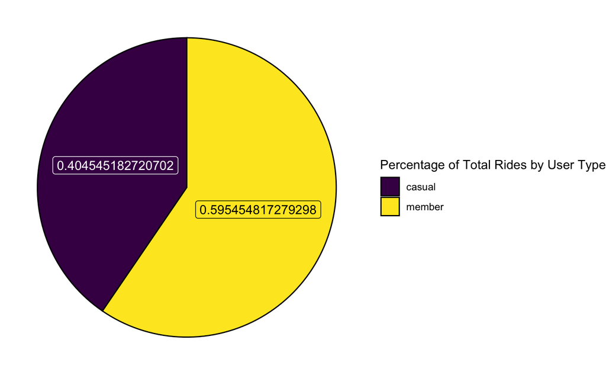

```r
ggplot(user_percent, aes(x = "", y = percent, fill = user_type)) +
  geom_col(color = "black") +
  geom_label(aes(label = percent), color = c("white", 1), position = position_stack(vjust = 0.5),show.legend = FALSE) +
  guides(fill = guide_legend(title = "Percentage of Total Rides by User Type")) +
  scale_fill_viridis_d() +
  coord_polar(theta = "y") +
  theme_void()
```

#### Count rides by user type by month (total = 4397887):

Note that month references should be changed to names.

```r
table(cyclistic_2021_2022_CLEAN$month)
```

```
    01     02     03     04     05     06     07     08     09     10     11     12
 79015  87606 212719 268413 493923 609513 630474 593928 525033 471244 252093 173926
```

#### Change month reference from integer to name:

Note that names are out of order now that data type is changed to string.

```r
cyclistic_analysis <- cyclistic_2021_2022_CLEAN %>% mutate(month = month.abb[as.numeric(month)])
table(cyclistic_analysis$month)
```

```
   Apr    Aug    Dec    Feb    Jan    Jul    Jun    Mar    May    Nov    Oct    Sep
268413 593928 173926  87606  79015 630474 609513 212719 493923 252093 471244 525033
```

#### Put months in order:

```r
cyclistic_analysis$month <- ordered(cyclistic_analysis$month, levels=c("Jan","Feb","Mar","Apr","May","Jun","Jul","Aug", "Sep", "Oct","Nov", "Dec"))
table(cyclistic_analysis$month)
```

```
   Jan    Feb    Mar    Apr    May    Jun    Jul    Aug    Sep    Oct    Nov    Dec
 79015  87606 212719 268413 493923 609513 630474 593928 525033 471244 252093 173926
```

### Count rides and their percentage by user type by month:

```r
rm(month_totals)
```

```r
 rides_by_month<- cyclistic_analysis %>%
  group_by(month, user_type) %>%
  summarize(total_rides = n()) %>%
  mutate(percent = (percent(total_rides/sum(total_rides))))
formattable(rides_by_month,
             align =c("l","c","c"),
           list('month' = color_tile("pink", "lightblue"), 'percent' = improvement_formatter))
```

| month | user_type | total_rides | percent |
| --- | --- | --- | --- |
| Jan | casual | 12461 | 15.77% |
| Jan | member | 66554 | 84.23% |
| Feb | casual | 14950 | 17.07% |
| Feb | member | 72656 | 82.93% |
| Mar | casual | 66329 | 31.18% |
| Mar | member | 146390 | 68.82% |
| Apr | casual | 90747 | 33.81% |
| Apr | member | 177666 | 66.19% |
| May | casual | 216860 | 43.91% |
| May | member | 277063 | 56.09% |
| Jun | casual | 287406 | 47.15% |
| Jun | member | 322107 | 52.85% |
| Jul | casual | 306378 | 48.59% |
| Jul | member | 324096 | 51.41% |
| Aug | casual | 265563 | 44.71% |
| Aug | member | 328365 | 55.29% |
| Sep | casual | 217375 | 41.40% |
| Sep | member | 307658 | 58.60% |
| Oct | casual | 187206 | 39.73% |
| Oct | member | 284038 | 60.27% |
| Nov | casual | 69225 | 27.46% |
| Nov | member | 182868 | 72.54% |
| Dec | casual | 44644 | 25.67% |
| Dec | member | 129282 | 74.33% |

#### Plot ride count by user type by month:

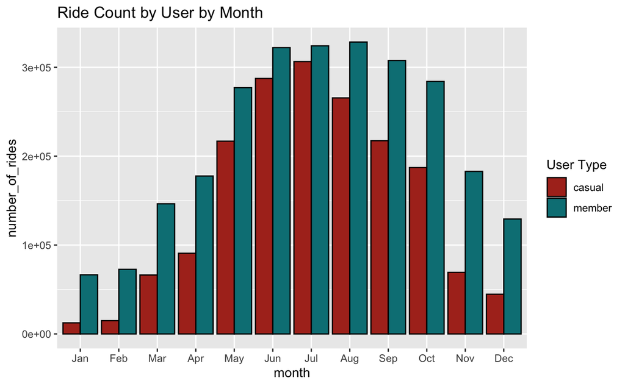

```r
cyclistic_analysis%>%
group_by(user_type, month)%>%
summarize(number_of_rides = n())%>%
arrange(user_type, month)%>%
ggplot(aes(x = month, y = number_of_rides, fill = user_type)) + geom_col(position = "dodge", color="black") +
  scale_fill_hue(l=40) +
  guides(fill = guide_legend(title = "User Type"))+
  ggtitle("Ride Count by User by Month")
```

#### Percentage rides by user type by month:

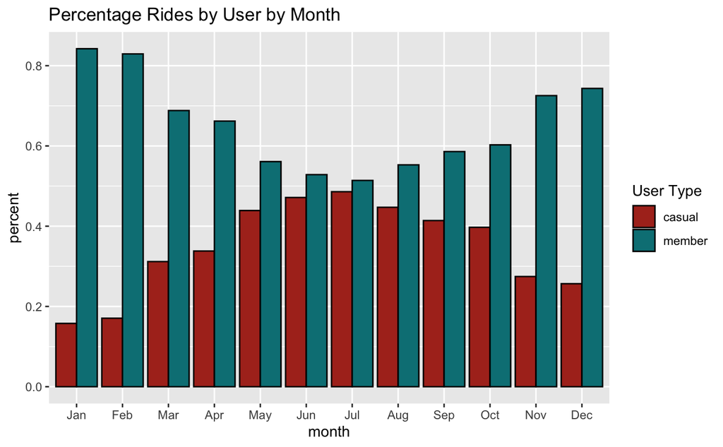

```r
cyclistic_analysis%>%
group_by(month, user_type)%>%
summarize(total_rides = n())%>%
mutate(percent = percent(total_rides / sum(total_rides)))%>%
arrange(user_type, month)%>%
ggplot(aes(x = month, y = percent, fill = user_type)) + geom_col(position = "dodge", color="black") +
  scale_fill_hue(l=40)+
  guides(fill = guide_legend (title = "User Type"))+
  ggtitle("Percentage Rides by User by Month")
```

#### Check total ride count for each user type by day of the week (total = 4397887):

```r
table(cyclistic_2021_2022_CLEAN$day_of_week)
```

```
   Friday    Monday  Saturday    Sunday  Thursday   Tuesday Wednesday
   626214    573444    726464    605710    626459    620765    618831
```

#### Put days of week in order:

```r
cyclistic_analysis$day_of_week <- ordered(cyclistic_analysis$day_of_week, levels=c("Sunday", "Monday", "Tuesday", "Wednesday", "Thursday", "Friday", "Saturday"))
table(cyclistic_analysis$day_of_week)
```

```
   Sunday    Monday   Tuesday Wednesday  Thursday    Friday  Saturday
   605710    573444    620765    618831    626459    626214    726464
```

#### Count rides and their percentage by user type by day of the week:

```r
rides_by_day_of_week<- cyclistic_analysis %>%
  group_by(day_of_week, user_type) %>%
  summarize(total_rides = n()) %>%
  mutate(percent = (percent(total_rides/sum(total_rides),0)))
formattable(rides_by_day_of_week,
             align =c("l","c","c"),
           list('day_of_week' = color_tile("pink", "lightblue"), 'percent' = improvement_formatter))
```

| day_of_week | user_type | total_rides | percent |
| --- | --- | --- | --- |
| Sunday | casual | 309192 | 51% |
| Sunday | member | 296518 | 49% |
| Monday | casual | 206822 | 36% |
| Monday | member | 366622 | 64% |
| Tuesday | casual | 199917 | 32% |
| Tuesday | member | 420848 | 68% |
| Wednesday | casual | 203274 | 33% |
| Wednesday | member | 415557 | 67% |
| Thursday | casual | 221681 | 35% |
| Thursday | member | 404778 | 65% |
| Friday | casual | 255838 | 41% |
| Friday | member | 370376 | 59% |
| Saturday | casual | 382420 | 53% |
| Saturday | member | 344044 | 47% |

#### Plot ride count by user type by day of the week:

```r
cyclistic_analysis%>%
group_by(user_type, day_of_week)%>%
summarize(number_of_rides = n())%>%
arrange(user_type, day_of_week)%>%
ggplot(aes(x = day_of_week, y = number_of_rides, fill = user_type)) + geom_col(position = "dodge", color="black") +
  scale_fill_hue(l=40) +
  guides(fill = guide_legend (title = "User Type"))+
  ggtitle("Ride Count by User by Day")
```

[output not shown]

#### Plot percentage of rides by user type by day of the week:

```r
cyclistic_analysis%>%
group_by(day_of_week, user_type)%>%
summarize(total_rides = n())%>%
mutate(percent=formattable::percent(total_rides/sum(total_rides)))%>%
arrange(user_type, day_of_week)%>%
ggplot(aes(x = day_of_week, y = percent, fill = user_type)) + geom_col(position = "dodge", color="black") +
  scale_fill_hue(l=40) +
  guides(fill = guide_legend (title = "User Type"))+
  ggtitle("Percentage of Rides by User by Day")
```

[output not shown]

### Aggregate trip duration by user type and bike type

#### Aggregate column trip duration:

```r
round(summary(cyclistic_analysis$trip_duration)/60)
```

```
   Min. 1st Qu.  Median    Mean 3rd Qu.    Max.
      1       6      11      18      20    1439
```

#### Aggregate trip duration by user type:

Note that the average duration of a casual user’s ride is roughly twice as long as a member’s ride.

```r
summary_trip_duration <- cyclistic_analysis %>%
  group_by(user_type) %>%
  summarize(average_duration=round((mean(trip_duration))/60),
            median_duration=round(median(trip_duration)/60),
            min_duration=round(min(trip_duration)/60),
            max_duration=round(max(trip_duration)/60))
formattable(summary_trip_duration)
```

| user_type | average_duration | median_duration | min_duration | max_duration |
| --- | --- | --- | --- | --- |
| casual | 25 | 14 | 1 | 1439 |
| member | 13 | 9 | 1 | 1435 |

#### Aggregate trip duration by user by month:

```r
improvement <- formatter("span", style = x ~ style(font.weight = "bold", color = ifelse(x > 20, "tomato", ifelse(x < 20, "steelblue", "black")))
                                   , x ~ icontext(ifelse(x >= 20, "arrow-up", "arrow-down"), x))
```

```r
by_month <- cyclistic_analysis%>%
group_by(month, user_type)%>%
summarize(average_duration=round((mean(trip_duration))/60))%>%
arrange(month, user_type)
formattable(by_month,
             align =c("l","c","c"),
           list('month' = color_tile("pink", "lightblue"), 'average_duration' = improvement))
```

| month | user_type | average_duration |
| --- | --- | --- |
| Jan | casual | 18 |
| Jan | member | 10 |
| Feb | casual | 22 |
| Feb | member | 11 |
| Mar | casual | 27 |
| Mar | member | 12 |
| Apr | casual | 26 |
| Apr | member | 12 |
| May | casual | 28 |
| May | member | 14 |
| Jun | casual | 25 |
| Jun | member | 14 |
| Jul | casual | 25 |
| Jul | member | 14 |
| Aug | casual | 24 |
| Aug | member | 13 |
| Sep | casual | 22 |
| Sep | member | 13 |
| Oct | casual | 25 |
| Oct | member | 12 |
| Nov | casual | 20 |
| Nov | member | 11 |
| Dec | casual | 20 |
| Dec | member | 11 |

#### Plot average trip duration by user by month:

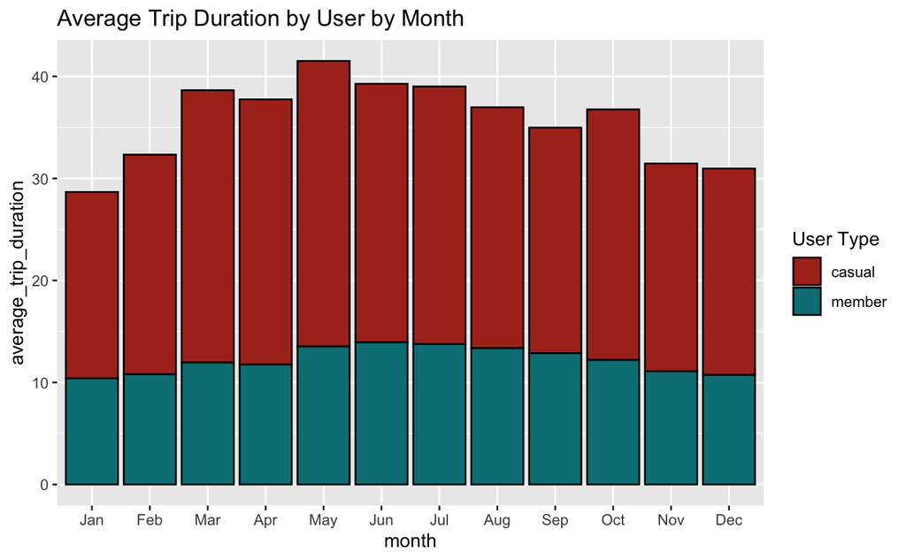

```r
cyclistic_analysis%>%
group_by(user_type, month) %>%
summarize(average_trip_duration = mean(trip_duration)/60) %>%
arrange(user_type, month) %>%
ggplot(aes(x = month, y = average_trip_duration, fill = user_type)) + geom_col(position = "stack", color="black") +
  scale_fill_hue(l=40) +
  guides(fill = guide_legend (title = "User Type"))+
  ggtitle("Average Trip Duration by User by Month")
```

#### Aggregate trip duration by user by day of the week:

```r
by_day_of_week <- cyclistic_analysis%>%
group_by(day_of_week, user_type)%>%
summarize(average_duration=round((mean(trip_duration))/60))%>%
arrange(day_of_week, user_type)
tibble(by_day_of_week)
```

| day_of_week | user_type | average_duration |
| --- | --- | --- |
| Sunday | casual | 28 |
| Sunday | member | 14 |
| Monday | casual | 25 |
| Monday | member | 12 |
| Tuesday | casual | 22 |
| Tuesday | member | 12 |
| Wednesday | casual | 21 |
| Wednesday | member | 12 |
| Thursday | casual | 22 |
| Thursday | member | 12 |

[output cut: 4 more lines]

```r
formattable(by_day_of_week,
             align =c("l","c","c"),
           list('day_of_week' = color_tile("pink", "lightblue"), 'average_duration' = improvement))
```

| day_of_week | user_type | average_duration |
| --- | --- | --- |
| Sunday | casual | 28 |
| Sunday | member | 14 |
| Monday | casual | 25 |
| Monday | member | 12 |
| Tuesday | casual | 22 |
| Tuesday | member | 12 |
| Wednesday | casual | 21 |
| Wednesday | member | 12 |
| Thursday | casual | 22 |
| Thursday | member | 12 |
| Friday | casual | 23 |
| Friday | member | 12 |
| Saturday | casual | 27 |
| Saturday | member | 14 |

#### Plot average trip duration by user by day of the week:

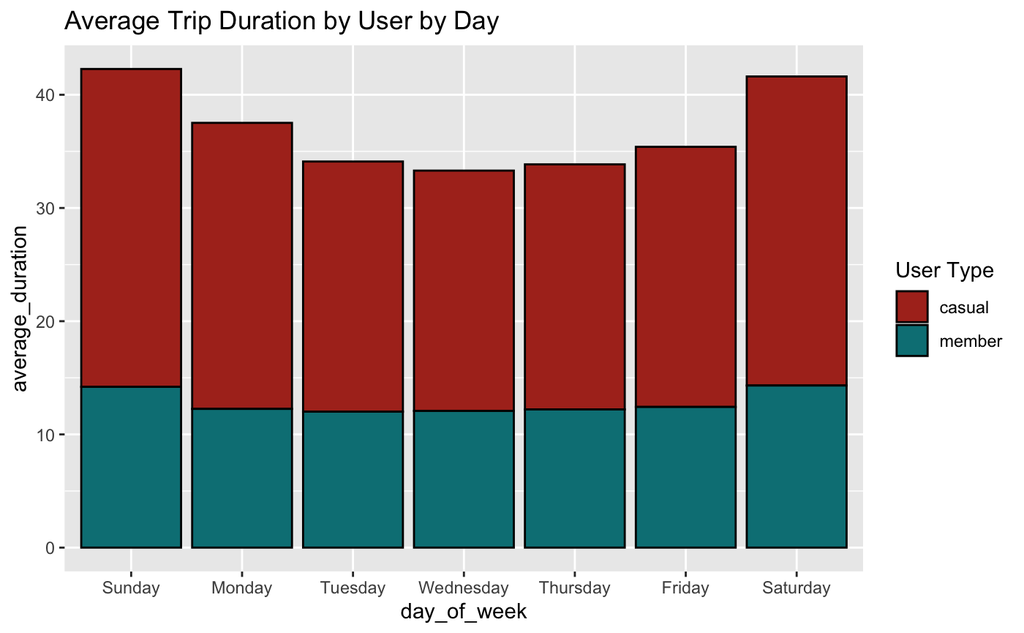

```r
cyclistic_analysis%>%
group_by(user_type, day_of_week) %>%
summarize(average_duration = mean(trip_duration)/60) %>%
arrange(user_type, day_of_week) %>%
ggplot(aes(x = day_of_week, y = average_duration, fill = user_type)) + geom_col(position = "stack", color="black") +
  scale_fill_hue(l=40) +
  guides(fill = guide_legend (title = "User Type"))+
  ggtitle("Average Trip Duration by User by Day")
```

### Total bike type usage by user type

#### Count rides and their percent of total by bike type:

```r
by_bike_type <- cyclistic_analysis %>%
  group_by(bike_type) %>%
  summarize(total_number = n()) %>%
  mutate(percent=percent(total_number/sum(total_number),0))
formattable(by_bike_type,
             align =c("l","c","r"),
           list('bike_type' = color_tile("pink", "red"), 'percent' = improvement_formatter))
```

| bike_type | total_number | percent |
| --- | --- | --- |
| classic_bike | 2695565 | 61% |
| docked_bike | 188124 | 4% |
| electric_bike | 1514198 | 34% |

#### Plot percentage of use by bike type:

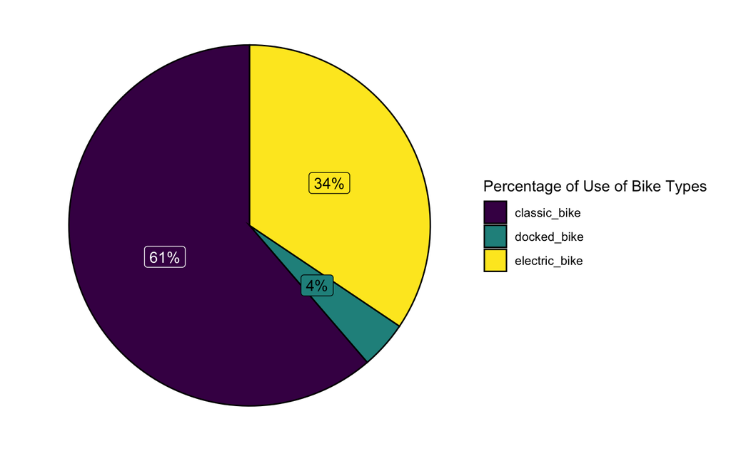

```r
ggplot(by_bike_type, aes(x = "", y = percent, fill = bike_type)) +
  geom_col(color = "black") +
  geom_label(aes(label = percent), color = c("white", 1, 1), position = position_stack(vjust = 0.5),show.legend = FALSE) +
  guides(fill = guide_legend(title = "Percentage of Use of Bike Types")) +
  scale_fill_viridis_d() +
  coord_polar(theta = "y") +
  theme_void()
```

#### Count rides and their percentage by bike and user type and aggregate average duration of those rides:

```r
bike_preference <- cyclistic_analysis %>%
  group_by(bike_type, user_type) %>%
  summarize(number_of_rides = n(), average_duration=round((mean(trip_duration))/60))%>%
  mutate(percent=percent(number_of_rides/sum(number_of_rides),0))%>%
  arrange(user_type, bike_type)
formattable(bike_preference,
             align =c("l","c","c"),
           list('bike_type' = color_tile("pink", "lightblue"), 'percent' = improvement_formatter))
```

[output not shown]

#### Plot ride count by bike and user type:

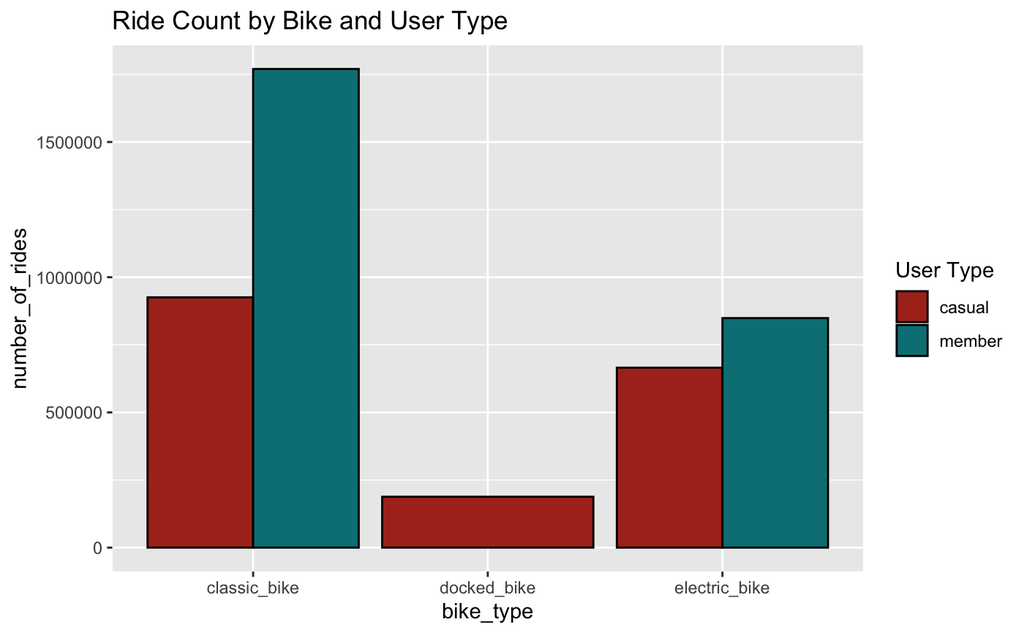

```r
bike_preference%>%
ggplot(aes(x = bike_type, y = number_of_rides, fill = user_type)) + geom_col(position = "dodge", color="black") +
  scale_fill_hue(l=40) +
  guides(fill = guide_legend (title = "User Type"))+
  ggtitle("Ride Count by Bike and User Type")
```

#### Plot percentage of rides by bike and user type:

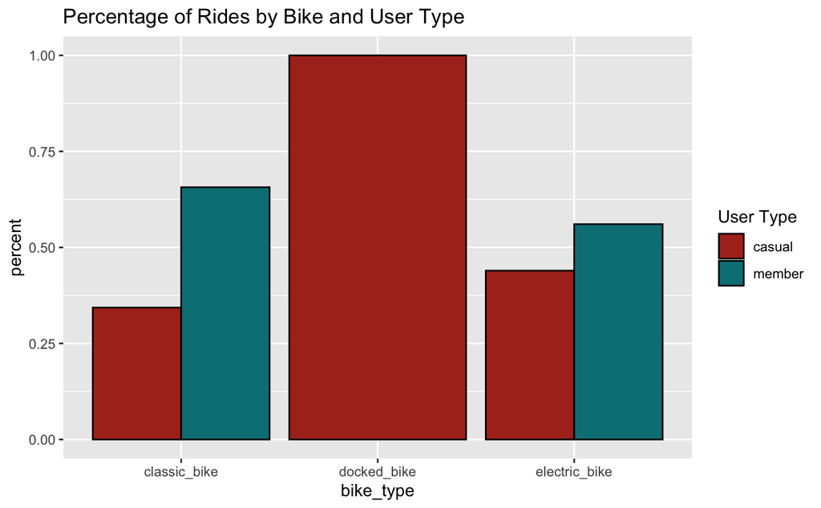

```r
bike_preference%>%
ggplot(aes(x = bike_type, y = percent, fill = user_type)) + geom_col(position = "dodge", color="black") +
  scale_fill_hue(l=40) +
  guides(fill = guide_legend (title = "User Type"))+
  ggtitle("Percentage of Rides by Bike and User Type")
```

#### Plot average duration of ride by bike and user type:

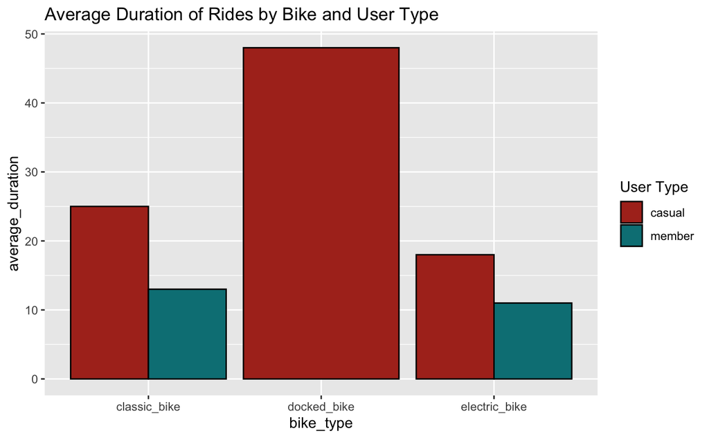

```r
bike_preference%>%
ggplot(aes(x = bike_type, y = average_duration, fill = user_type)) +
             geom_col(position = "dodge", color="black") +
  scale_fill_hue(l=40) +
  guides(fill = guide_legend (title = "User Type"))+
  ggtitle("Average Duration of Rides by Bike and User Type")
```

#### Create two pie charts comparatively demonstrating percentage of use of bike type by user type.

##### Count rides and their percentage by bike type by casual user:

```r
by_casual <- cyclistic_analysis %>%
  filter(user_type == "casual") %>%
  group_by(user_type, bike_type) %>%
  summarize(total_number = n(), percent = n()) %>%
  mutate(percent = percent(percent / sum(percent),0))
formattable(by_casual,
             align =c("l","c","c", "r"),
           list('bike_type' = color_tile("pink", "lightblue"), 'percent' = improvement_formatter))
```

| user_type | bike_type | total_number | percent |
| --- | --- | --- | --- |
| casual | classic_bike | 925549 | 52% |
| casual | docked_bike | 188124 | 11% |
| casual | electric_bike | 665471 | 37% |

##### Plot percentage of bike type used by casual user:

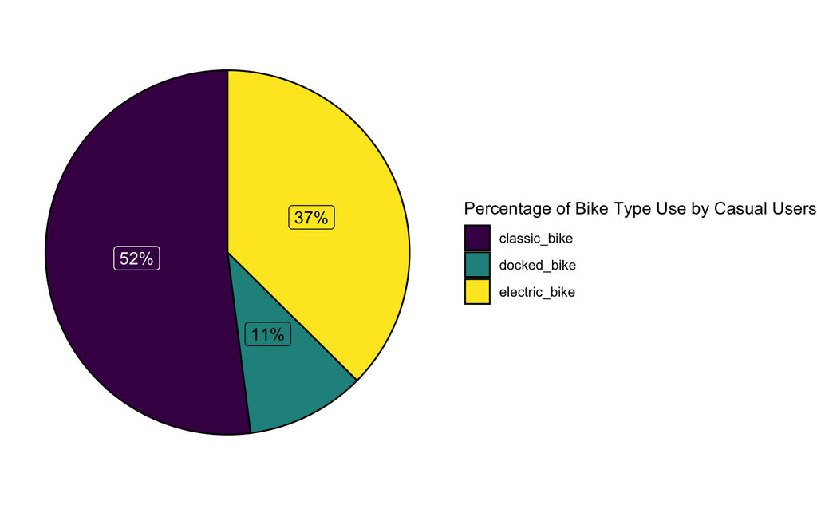

```r
ggplot(by_casual, aes(x = "", y = percent, fill = bike_type)) +
  geom_col(color = "black") +
  geom_label(aes(label = percent), color = c("white", 1, 1), position = position_stack(vjust = 0.5),show.legend = FALSE) +
  guides(fill = guide_legend(title = "Percentage of Bike Type Use by Casual Users")) +
  scale_fill_viridis_d() +
  coord_polar(theta = "y") +
  theme_void()
```

```r
by_member <- cyclistic_analysis %>%
  filter(user_type == "member") %>%
  group_by(user_type, bike_type) %>%
  summarize(total_number = n(), percent = n()) %>%
  mutate(percent = percent(percent / sum(percent),0))
formattable(by_casual,
             align =c("l","c","c", "r"),
           list('bike_type' = color_tile("pink", "lightblue"), 'percent' = improvement_formatter))
```

| user_type | bike_type | total_number | percent |
| --- | --- | --- | --- |
| casual | classic_bike | 925549 | 52% |
| casual | docked_bike | 188124 | 11% |
| casual | electric_bike | 665471 | 37% |

##### Plot percentage of bike type used by member user:

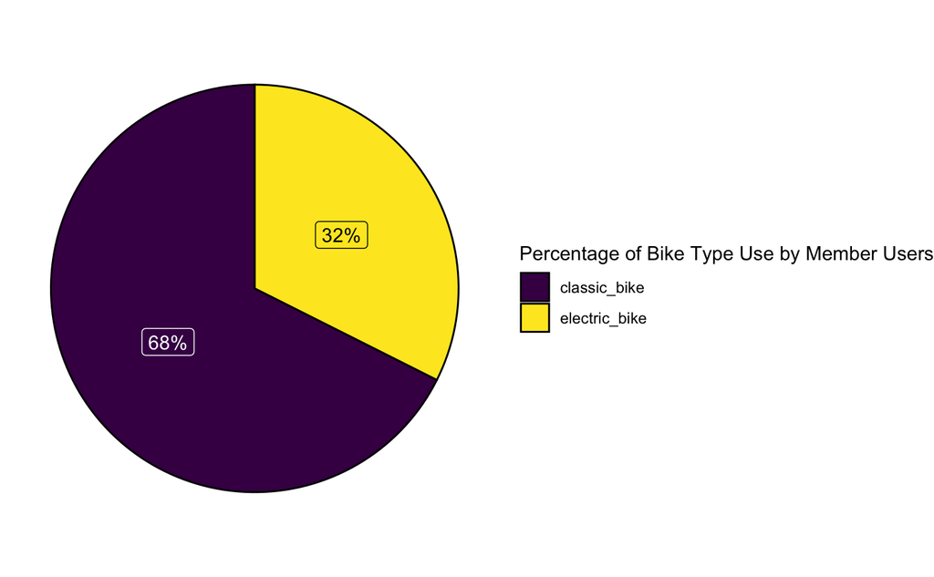

```r
ggplot(by_member, aes(x = "", y = percent, fill = bike_type)) +
  geom_col(color = "black") +
  geom_label(aes(label = percent), color = c("white", 1), position = position_stack(vjust = 0.5),show.legend = FALSE) +
  guides(fill = guide_legend(title = "Percentage of Bike Type Use by Member Users")) +
  scale_fill_viridis_d() +
  coord_polar(theta = "y") +
  theme_void()
```

### Investigate station use by user type

#### Create new boolean column to calculate round trips based on station ids:

```r
cyclistic_analysis_V2 <- cyclistic_analysis %>%
  mutate(round_trip = start_station_id == end_station_id)
```

#### Compare number and percentage of round trips and their average duration by user:

```r
round_trip <- cyclistic_analysis_V2 %>%
  group_by(user_type, round_trip) %>%
 summarize(number_of_rides = n(), average_duration = round(mean(trip_duration)/60))%>%
  mutate(percent_round_trips = percent(number_of_rides / sum(number_of_rides),0))%>%
  arrange(user_type, round_trip)
formattable(round_trip,
             align =c("l","c","c", "c", "r"),
           list('bike_type' = color_tile("pink", "lightblue"), 'percent_round_trips' = formatter("span", style = x ~ style(font.weight = "bold", color = ifelse(x > .90, "tomato", ifelse(x < .90, "steelblue", "black"))))))
```

| user_type | round_trip | number_of_rides | average_duration | percent_round_trips |
| --- | --- | --- | --- | --- |
| casual | FALSE | 1624973 | 23 | 91% |
| casual | TRUE | 154171 | 43 | 9% |
| member | FALSE | 2546402 | 12 | 97% |
| member | TRUE | 72341 | 22 | 3% |

#### Plot percentage of round trips by user:

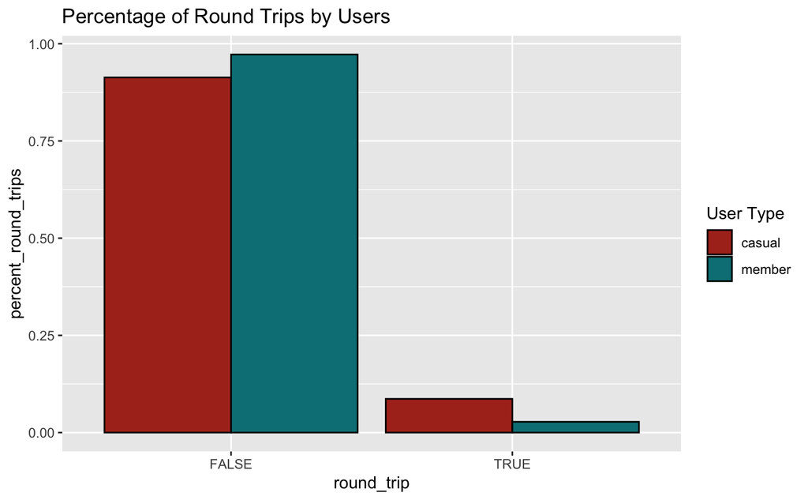

```r
round_trip %>%
  ggplot(aes(x = round_trip, y = percent_round_trips, fill = user_type)) +
             geom_col(position = "dodge", color="black") +
  scale_fill_hue(l=40) +
guides(fill = guide_legend (title = "User Type"))+
  ggtitle("Percentage of Round Trips by Users")
```

#### Compare number and percentage of round trips and their average duration by user and bike type:

```r
round_trip <- cyclistic_analysis_V2 %>%
  group_by(user_type, round_trip, bike_type) %>%
 summarize(number_of_rides = n(), average_duration = round(mean(trip_duration)/60))%>%
  mutate(percent_round_trips = percent(number_of_rides / sum(number_of_rides),0))%>%
  arrange(user_type, round_trip, bike_type)
formattable(round_trip, align =c("l","c","c","c","c","r"),
           list('percent_round_trips' = formatter("span", style = x ~ style(font.weight = "bold"))))
```

| user_type | round_trip | bike_type | number_of_rides | average_duration | percent_round_trips |
| --- | --- | --- | --- | --- | --- |
| casual | FALSE | classic_bike | 849919 | 23 | 52% |
| casual | FALSE | docked_bike | 156165 | 45 | 10% |
| casual | FALSE | electric_bike | 618889 | 17 | 38% |
| casual | TRUE | classic_bike | 75630 | 42 | 49% |
| casual | TRUE | docked_bike | 31959 | 66 | 21% |
| casual | TRUE | electric_bike | 46582 | 28 | 30% |
| member | FALSE | classic_bike | 1718464 | 13 | 67% |
| member | FALSE | electric_bike | 827938 | 11 | 33% |
| member | TRUE | classic_bike | 51552 | 24 | 71% |
| member | TRUE | electric_bike | 20789 | 16 | 29% |

#### Plot percentage of round trips by user and bike type:

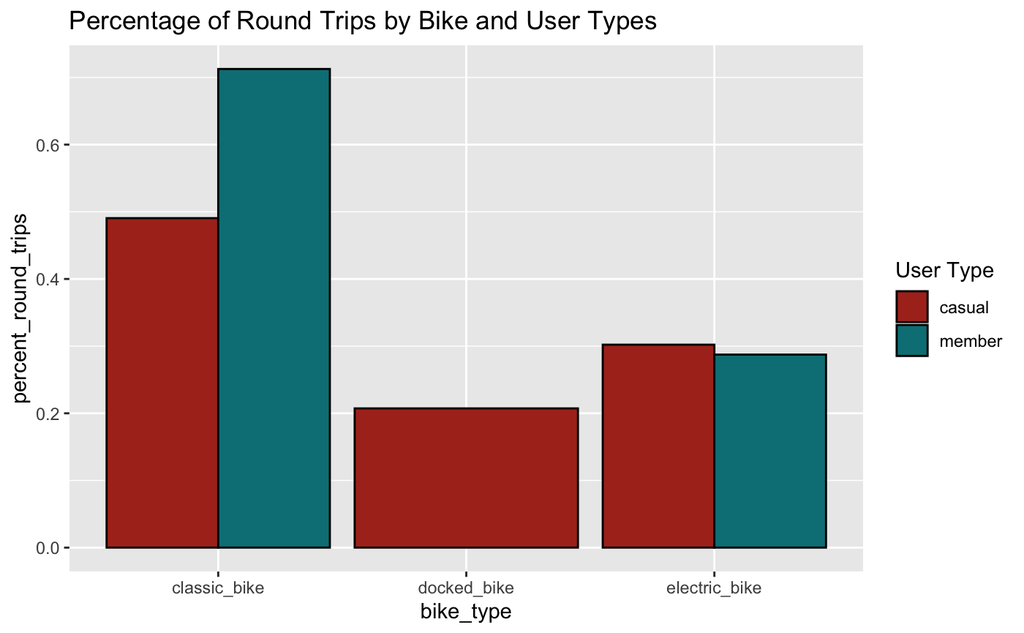

```r
round_trip_TRUE <- round_trip %>%
  filter(round_trip == TRUE)
round_trip_TRUE %>%
  ggplot(aes(x = bike_type, y = percent_round_trips, fill = user_type)) +
             geom_col(position = "dodge", color="black") +
  scale_fill_hue(l=40) +
guides(fill = guide_legend (title = "User Type"))+
  ggtitle("Percentage of Round Trips by Bike and User Types")
```

### Investigate most and least used stations of user types.

#### Calculate most and least used stations of both user types:

```r
most_popular_stations <- cyclistic_analysis_V2 %>%
  group_by(start_station_id, start_station_name) %>%
  summarize(number_of_rides = n(),average_duration = round(mean(trip_duration)/60))%>%
  arrange(desc(number_of_rides))%>%
  head(n = 5)
formattable(most_popular_stations)
```

| start_station_id | start_station_name | number_of_rides | average_duration |
| --- | --- | --- | --- |
| 13022 | Streeter Dr & Grand Ave | 70719 | 33 |
| 13300 | DuSable Lake Shore Dr & Monroe St | 39310 | 34 |
| LF-005 | DuSable Lake Shore Dr & North Blvd | 37616 | 25 |
| 13042 | Michigan Ave & Oak St | 37111 | 31 |
| TA1308000050 | Wells St & Concord Ln | 35990 | 14 |

#### Calculate most used station of causal rider:

```r
most_popular_casual <- cyclistic_analysis_V2 %>%
  filter(user_type == "casual") %>%
  group_by(start_station_id, start_station_name) %>%
  summarize(number_of_rides=n(), average_duration=round(mean(trip_duration)/60))%>%
  arrange(desc(number_of_rides))%>%
  head(n = 5)
formattable(most_popular_casual)
```

| start_station_id | start_station_name | number_of_rides | average_duration |
| --- | --- | --- | --- |
| 13022 | Streeter Dr & Grand Ave | 54792 | 37 |
| 13300 | DuSable Lake Shore Dr & Monroe St | 30270 | 37 |
| 13008 | Millennium Park | 25080 | 41 |
| 13042 | Michigan Ave & Oak St | 23659 | 37 |
| LF-005 | DuSable Lake Shore Dr & North Blvd | 22130 | 30 |

#### Calculate most taken casual trips from the most used start station:

Note that Streeter Dr & Grand Ave is Navy Pier on the Lakefront Trail.

```r
LFT <- cyclistic_analysis_V2 %>%
  filter(user_type == "casual", start_station_name == "Streeter Dr & Grand Ave") %>%
  group_by(start_station_name, end_station_name)%>%
    summarize(number_of_rides = n(),average_duration=round(mean(trip_duration)/60))%>%
arrange(desc(number_of_rides))%>%
  head(n = 5)
formattable(LFT)
```

| start_station_name | end_station_name | number_of_rides | average_duration |
| --- | --- | --- | --- |
| Streeter Dr & Grand Ave | Streeter Dr & Grand Ave | 9673 | 45 |
| Streeter Dr & Grand Ave | DuSable Lake Shore Dr & Monroe St | 2899 | 28 |
| Streeter Dr & Grand Ave | Millennium Park | 2873 | 34 |
| Streeter Dr & Grand Ave | Michigan Ave & Oak St | 2366 | 30 |
| Streeter Dr & Grand Ave | DuSable Lake Shore Dr & North Blvd | 2151 | 26 |

#### Calculate most used station of member rider:

```r
most_popular_member <- cyclistic_analysis_V2 %>%
  filter(user_type == "member") %>%
  group_by(start_station_id, start_station_name) %>%
  summarize(number_of_rides = n(),average_duration=round(mean(trip_duration)/60))%>%
  arrange(desc(number_of_rides))%>%
  head(n = 5)
formattable(most_popular_member)
```

| start_station_id | start_station_name | number_of_rides | average_duration |
| --- | --- | --- | --- |
| KA1503000043 | Kingsbury St & Kinzie St | 24567 | 9 |
| TA1307000039 | Clark St & Elm St | 21451 | 12 |
| TA1308000050 | Wells St & Concord Ln | 20645 | 12 |
| WL-012 | Clinton St & Washington Blvd | 18654 | 11 |
| TA1305000032 | Clinton St & Madison St | 18483 | 11 |

Note that Clinton St & Madison St is Union Station.

```r
Union_Station <- cyclistic_analysis_V2 %>%
  filter(user_type == "member", start_station_name == "Clinton St & Madison St") %>%
  group_by(start_station_name, end_station_name)%>%
    summarize(number_of_rides = n(),average_duration=round(mean(trip_duration)/60))%>%
arrange(desc(number_of_rides))%>%
  head(n = 5)
formattable(Union_Station)
```

| start_station_name | end_station_name | number_of_rides | average_duration |
| --- | --- | --- | --- |
| Clinton St & Madison St | Kingsbury St & Kinzie St | 537 | 6 |
| Clinton St & Madison St | Desplaines St & Kinzie St | 533 | 6 |
| Clinton St & Madison St | 900 W Harrison St | 383 | 8 |
| Clinton St & Madison St | Green St & Madison St | 360 | 5 |
| Clinton St & Madison St | Clinton St & Lake St | 348 | 6 |

```r
write.csv(Union_Station, "most_popular_member_trips.csv")
```

#### Calculate least used stations of user types:

```r
least_popular <- cyclistic_analysis_V2 %>%
  group_by(start_station_name) %>%
  summarize(number_of_rides = n())%>%
  arrange(number_of_rides)%>%
  head(n = 5)
formattable(least_popular)
```

| start_station_name | number_of_rides |
| --- | --- |
| 10101 S Stony Island Ave | 1 |
| 83rd St (Avalon Park) Metra | 1 |
| Ada St & 117th St | 1 |
| Ada St & 79th St | 1 |
| Ada St & 95th St | 1 |

#### Calculate least used stations of casual users:

```r
least_popular_casual <- cyclistic_analysis_V2 %>%
  filter(user_type == "casual") %>%
  group_by(start_station_name) %>%
  summarize(number_of_rides = n())%>%
  arrange(number_of_rides)%>%
  head(n = 5)
formattable(least_popular_casual)
```

| start_station_name | number_of_rides |
| --- | --- |
| 10101 S Stony Island Ave | 1 |
| 83rd St (Avalon Park) Metra | 1 |
| Ada St & 117th St | 1 |
| Ada St & 79th St | 1 |
| Ada St & 95th St | 1 |

```r
least_popular_member <- cyclistic_analysis_V2 %>%
  filter(user_type == "casual") %>%
  group_by(start_station_name) %>%
  summarize(number_of_rides = n())%>%
  arrange(number_of_rides)%>%
  head(n = 5)
formattable(least_popular_member)
```

| start_station_name | number_of_rides |
| --- | --- |
| 10101 S Stony Island Ave | 1 |
| 83rd St (Avalon Park) Metra | 1 |
| Ada St & 117th St | 1 |
| Ada St & 79th St | 1 |
| Ada St & 95th St | 1 |